# Project_NN

## Import Libraries.

```python
import pandas as pd
import numpy as np
from sklearn.model_selection import train_test_split
from sklearn import preprocessing
from tensorflow.keras.models import Sequential
from tensorflow.keras.layers import Dense, Dropout, BatchNormalization
from sklearn.metrics import accuracy_score, confusion_matrix, precision_score, recall_score, f1_score, precision_recall_curve, auc
import matplotlib.pyplot as plt
from tensorflow.keras import optimizers
from keras.utils import np_utils
import seaborn as sns
from skimage import color
from skimage import io
import h5py
import tensorflow as tf
from tensorflow.keras.layers import Activation
from keras import optimizers
%matplotlib inline
plt.rcParams['figure.figsize'] = (16.0, 4.0)
```

## Load data.

```python
df = h5py.File('C:\\Users\\HP\\Downloads\\SVHN_single_grey1 (1).h5', 'r')
```

## Dataset attributes.

```python
df.keys()
```

```
<KeysViewHDF5 ['X_test', 'X_train', 'X_val', 'y_test', 'y_train', 'y_val']>
```

```python
X_train=df['X_train']
X_test=df['X_test']
X_val=df['X_val']
y_train=df['y_train']
y_test=df['y_test']
y_val=df['y_val']
```

## Dataset distribution and datatype.

```python
print("Training data X Shape :", X_train.shape,"and data Type : ", X_train.dtype)
print("Testing data X Shape :", X_test.shape,"and data Type : ", X_test.dtype)
print("Validation data X Shape :", X_val.shape,"and data Type : ", X_val.dtype)
print("Training data y Shape :", y_train.shape,"and data Type : ", y_train.dtype)
print("Testing data y Shape :", y_test.shape,"and data Type : ", y_test.dtype)
print("Validation data y Shape :", y_val.shape,"and data Type : ", y_val.dtype)
```

```
Training data X Shape : (42000, 32, 32) and data Type :  float32
Testing data X Shape : (18000, 32, 32) and data Type :  float32
Validation data X Shape : (60000, 32, 32) and data Type :  float32
Training data y Shape : (42000,) and data Type :  uint8
Testing data y Shape : (18000,) and data Type :  uint8
Validation data y Shape : (60000,) and data Type :  uint8
```

## Visualisation..

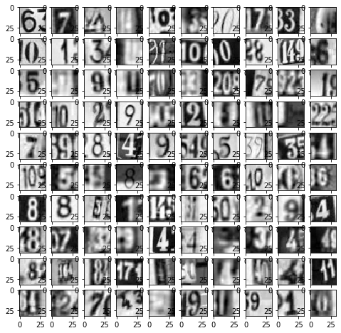

```python
fig=plt.figure(figsize=(8,8))
columns=10
rows=10
for i in range(1, columns*rows+1):
    img= X_train[i]
    fig.add_subplot(rows,columns,i)
    plt.imshow(img,cmap='gray')
plt.show()
```

## Visualising first 10 elements..

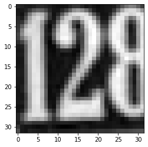

```
Label:  2
```

```python
plt.imshow(X_train[0],cmap='gray')
plt.show()
print('Label: ', y_train[0])
```

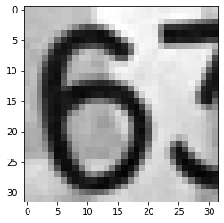

```
Label:  6
```

```python
plt.imshow(X_train[1],cmap='gray')
plt.show()
print('Label: ', y_train[1])
```

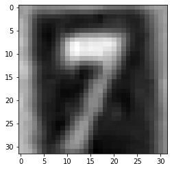

```
Label:  7
```

```python
plt.imshow(X_train[2],cmap='gray')
plt.show()
print('Label: ', y_train[2])
```

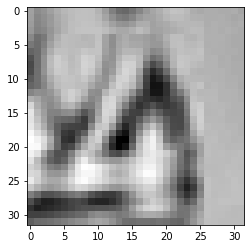

```
Label:  4
```

```python
plt.imshow(X_train[3],cmap='gray')
plt.show()
print('Label: ', y_train[3])
```

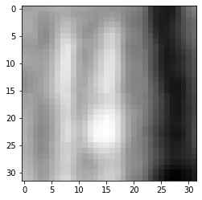

```
Label:  4
```

```python
plt.imshow(X_train[4],cmap='gray')
plt.show()
print('Label: ', y_train[4])
```

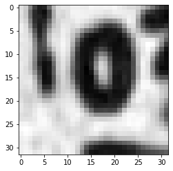

```
Label:  0
```

```python
plt.imshow(X_train[5],cmap='gray')
plt.show()
print('Label: ', y_train[5])
```

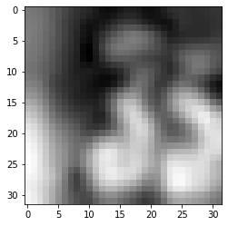

```
Label:  3
```

```python
plt.imshow(X_train[6],cmap='gray')
plt.show()
print('Label: ', y_train[6])
```

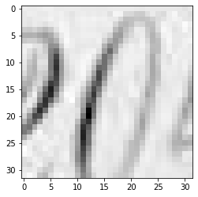

```
Label:  0
```

```python
plt.imshow(X_train[7],cmap='gray')
plt.show()
print('Label: ', y_train[7])
```

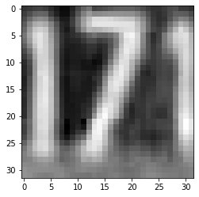

```
Label:  7
```

```python
plt.imshow(X_train[8],cmap='gray')
plt.show()
print('Label: ', y_train[8])
```

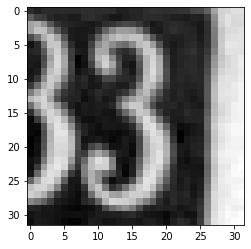

```
Label:  3
```

```python
plt.imshow(X_train[9],cmap='gray')
plt.show()
print('Label: ', y_train[9])
```

## Preprocessing the data.

### Reshaping the input data.

```python
X_train = np.asarray(X_train).reshape(42000,1024)

X_test = np.asarray(X_test).reshape(18000,1024)

X_val = np.asarray(X_val).reshape(60000,1024)
```

### Normalizing the data.

```python
X_train = preprocessing.normalize(X_train)
X_test = preprocessing.normalize(X_test)
X_val = preprocessing.normalize(X_val)
```

### Converting output data into one hot vectors.

```python
y_train = tf.keras.utils.to_categorical(y_train, num_classes=10)

y_test = tf.keras.utils.to_categorical(y_test, num_classes=10)

y_val = tf.keras.utils.to_categorical(y_val, num_classes=10)
```

### Shape of the data.

```python
print(X_train.shape, X_test.shape,X_val.shape, y_train.shape, y_test.shape,y_val.shape)
```

```
(42000, 1024) (18000, 1024) (60000, 1024) (42000, 10) (18000, 10) (60000, 10)
```

## Basic NN model.

```python
M1 = Sequential()
```

```python
M1.add(Dense(512, kernel_initializer='he_normal',input_shape = (1024, )))
M1.add(Activation('relu'))

M1.add(Dense(256, kernel_initializer='he_normal'))
M1.add(Activation('relu'))

M1.add(Dense(128, kernel_initializer='he_normal'))
M1.add(Activation('relu'))

M1.add(Dense(64, kernel_initializer='he_normal'))
M1.add(Activation('relu'))

M1.add(Dense(32, kernel_initializer='he_normal'))
M1.add(Activation('relu'))

M1.add(Dense(10))
M1.add(Activation('softmax'))
```

[output not shown]

```python
M1.summary()
```

```
_________________________________________________________________
Layer (type)                 Output Shape              Param #
=================================================================
dense (Dense)                (None, 512)               524800
_________________________________________________________________
activation (Activation)      (None, 512)               0
_________________________________________________________________
dense_1 (Dense)              (None, 256)               131328
_________________________________________________________________
activation_1 (Activation)    (None, 256)               0
_________________________________________________________________
dense_2 (Dense)              (None, 128)               32896
_________________________________________________________________
activation_2 (Activation)    (None, 128)               0
_________________________________________________________________
dense_3 (Dense)              (None, 64)                8256
_________________________________________________________________
activation_3 (Activation)    (None, 64)                0
_________________________________________________________________
dense_4 (Dense)              (None, 32)                2080
_________________________________________________________________
activation_4 (Activation)    (None, 32)                0
_________________________________________________________________
dense_5 (Dense)              (None, 10)                330
_________________________________________________________________
activation_5 (Activation)    (None, 10)                0
=================================================================
Total params: 699,690
Trainable params: 699,690
Non-trainable params: 0
_________________________________________________________________
```

### Implementing optimizer [SGD].

```python
M1.compile(optimizer = 'sgd', loss = 'categorical_crossentropy', metrics = ['accuracy'])
```

```python
history = M1.fit(X_train, y_train, validation_data=(X_val,y_val),batch_size = 200, epochs = 10, verbose = 1)
```

```
Train on 42000 samples, validate on 60000 samples
WARNING:tensorflow:From C:\Users\HP\AppData\Local\Continuum\anaconda3\lib\site-packages\tensorflow\python\ops\math_ops.py:3066: to_int32 (from tensorflow.python.ops.math_ops) is deprecated and will be removed in a future version.
Instructions for updating:
Use tf.cast instead.
```

### Model evaluation.

```python
R1 = M1.evaluate(X_val, y_val)
print('Validation accuracy using SGD optimizer : ', R1[1])
```

```
Validation accuracy using SGD optimizer :  0.20353334
```

### Model performance with SGD optimizer is low with accuracy of 20%.

### Implementing optimizer [ADAM].

```python
M1.compile(optimizer = 'adam', loss = 'categorical_crossentropy', metrics = ['accuracy'])
```

```python
history = M1.fit(X_train, y_train, validation_data=(X_val,y_val),batch_size = 200, epochs = 10, verbose = 1)
```

```
Train on 42000 samples, validate on 60000 samples
```

```python
R2 = M1.evaluate(X_val, y_val)
print('Validation accuracy using adam: ', R2[1])
```

```
Validation accuracy using adam:  0.7273167
```

### Model performance with Adam optimizer increases to 72%.

### Implementing optimizer [SGD] with learning rate 0.0001.

```python
sgd = optimizers.SGD(lr = 0.0001)

M1.compile(optimizer = 'sgd', loss = 'categorical_crossentropy', metrics = ['accuracy'])

history = M1.fit(X_train, y_train, validation_data=(X_val,y_val),batch_size = 200, epochs = 10, verbose = 1)
```

```
Train on 42000 samples, validate on 60000 samples
```

```python
R3 = M1.evaluate(X_val, y_val)
print('Validation accuracy using sgd with lr: ', R3[1])
```

```
Validation accuracy using sgd with lr:  0.7531667
```

### Implementing optimizer [Adam] with learning rate 0.0001.

```python
adam = optimizers.adam(lr = 0.0001)

M1.compile(optimizer = 'adam', loss = 'categorical_crossentropy', metrics = ['accuracy'])

history = M1.fit(X_train, y_train, validation_data=(X_val,y_val),batch_size = 200, epochs = 10, verbose = 1)
```

```
Train on 42000 samples, validate on 60000 samples
```

```python
R4 = M1.evaluate(X_val, y_val)
print('Validation accuracy using adam with lr: ', R4[1])
```

```
Validation accuracy using adam with lr:  0.7876833
```

```python
results_on_val = pd.DataFrame({'Method':['NN'], 'accuracy': R4[1]},index={'1'})
results_on_val = results_on_val[['Method', 'accuracy']]
results_on_val
```

|  | Method | accuracy |
| --- | --- | --- |
| 1 | NN | 0.787683 |

## Implementing Batch Normalization.

### (1) With optimizer [Adam].

```python
M2 = Sequential()
```

```python
M2.add(Dense(512, kernel_initializer='he_normal',input_shape = (1024, )))
M2.add(BatchNormalization())
M2.add(Activation('relu'))

M2.add(Dense(256, kernel_initializer='he_normal'))
M2.add(BatchNormalization())
M2.add(Activation('relu'))

M2.add(Dense(128, kernel_initializer='he_normal'))
M2.add(BatchNormalization())
M2.add(Activation('relu'))

M2.add(Dense(64, kernel_initializer='he_normal'))
M2.add(BatchNormalization())
M2.add(Activation('relu'))

M2.add(Dense(32, kernel_initializer='he_normal'))
M2.add(BatchNormalization())
M2.add(Activation('relu'))

M2.add(Dense(10))
M2.add(Activation('softmax'))
```

```python
M2.summary()
```

```
_________________________________________________________________
Layer (type)                 Output Shape              Param #
=================================================================
dense_6 (Dense)              (None, 512)               524800
_________________________________________________________________
batch_normalization_v1 (Batc (None, 512)               2048
_________________________________________________________________
activation_6 (Activation)    (None, 512)               0
_________________________________________________________________
dense_7 (Dense)              (None, 256)               131328
_________________________________________________________________
batch_normalization_v1_1 (Ba (None, 256)               1024
_________________________________________________________________
activation_7 (Activation)    (None, 256)               0
_________________________________________________________________
dense_8 (Dense)              (None, 128)               32896
_________________________________________________________________
batch_normalization_v1_2 (Ba (None, 128)               512
_________________________________________________________________
activation_8 (Activation)    (None, 128)               0
_________________________________________________________________
dense_9 (Dense)              (None, 64)                8256
_________________________________________________________________
batch_normalization_v1_3 (Ba (None, 64)                256
_________________________________________________________________
activation_9 (Activation)    (None, 64)                0
_________________________________________________________________
dense_10 (Dense)             (None, 32)                2080
_________________________________________________________________
batch_normalization_v1_4 (Ba (None, 32)                128
_________________________________________________________________
activation_10 (Activation)   (None, 32)                0
_________________________________________________________________
dense_11 (Dense)             (None, 10)                330
_________________________________________________________________
activation_11 (Activation)   (None, 10)                0
=================================================================
Total params: 703,658
Trainable params: 701,674
Non-trainable params: 1,984
_________________________________________________________________
```

```python
adam = optimizers.adam(lr = 0.0001)

M2.compile(optimizer = 'adam', loss = 'categorical_crossentropy', metrics = ['accuracy'])
```

```python
history_1 = M2.fit(X_train, y_train, validation_data=(X_val,y_val),batch_size = 200, epochs = 10, verbose = 1)
```

```
Train on 42000 samples, validate on 60000 samples
```

```python
results_1 =M2.evaluate(X_val, y_val)
print('Val_acc using batch adam : ', results_1[1])
```

```
Val_acc using batch adam :  0.82463336
```

```python
tempResultsDf = pd.DataFrame({'Method':['NN_Batch_adam'], 'accuracy': [results_1[1]]},index={'2'})
results_on_val= pd.concat([results_on_val, tempResultsDf])
results_on_val = results_on_val[['Method', 'accuracy']]
results_on_val
```

|  | Method | accuracy |
| --- | --- | --- |
| 1 | NN | 0.787683 |
| 2 | NN_Batch_adam | 0.824633 |

### Adding the Batch normalization [Adam optimizer] , our model performance increases from TO 78% FROM 82%.

### (2) With optimizer [SGD].

```python
M3 = Sequential()
```

```python
M3.add(Dense(512, kernel_initializer='he_normal',input_shape = (1024, )))
M3.add(BatchNormalization())
M3.add(Activation('relu'))

M3.add(Dense(256, kernel_initializer='he_normal'))
M3.add(BatchNormalization())
M3.add(Activation('relu'))

M3.add(Dense(128, kernel_initializer='he_normal'))
M3.add(BatchNormalization())
M3.add(Activation('relu'))

M3.add(Dense(64, kernel_initializer='he_normal'))
M3.add(BatchNormalization())
M3.add(Activation('relu'))

M3.add(Dense(32, kernel_initializer='he_normal'))
M3.add(BatchNormalization())
M3.add(Activation('relu'))

M3.add(Dense(10))
M3.add(Activation('softmax'))
```

```python
M3.summary()
```

```
_________________________________________________________________
Layer (type)                 Output Shape              Param #
=================================================================
dense_12 (Dense)             (None, 512)               524800
_________________________________________________________________
batch_normalization_v1_5 (Ba (None, 512)               2048
_________________________________________________________________
activation_12 (Activation)   (None, 512)               0
_________________________________________________________________
dense_13 (Dense)             (None, 256)               131328
_________________________________________________________________
batch_normalization_v1_6 (Ba (None, 256)               1024
_________________________________________________________________
activation_13 (Activation)   (None, 256)               0
_________________________________________________________________
dense_14 (Dense)             (None, 128)               32896
_________________________________________________________________
batch_normalization_v1_7 (Ba (None, 128)               512
_________________________________________________________________
activation_14 (Activation)   (None, 128)               0
_________________________________________________________________
dense_15 (Dense)             (None, 64)                8256
_________________________________________________________________
batch_normalization_v1_8 (Ba (None, 64)                256
_________________________________________________________________
activation_15 (Activation)   (None, 64)                0
_________________________________________________________________
dense_16 (Dense)             (None, 32)                2080
_________________________________________________________________
batch_normalization_v1_9 (Ba (None, 32)                128
_________________________________________________________________
activation_16 (Activation)   (None, 32)                0
_________________________________________________________________
dense_17 (Dense)             (None, 10)                330
_________________________________________________________________
activation_17 (Activation)   (None, 10)                0
=================================================================
Total params: 703,658
Trainable params: 701,674
Non-trainable params: 1,984
_________________________________________________________________
```

```python
sgd = optimizers.sgd(lr = 0.0001)

M3.compile(optimizer = 'sgd', loss = 'categorical_crossentropy', metrics = ['accuracy'])
```

```python
history_2 = M3.fit(X_train, y_train, validation_data=(X_val,y_val),batch_size = 200, epochs = 10, verbose = 1)
```

```
Train on 42000 samples, validate on 60000 samples
```

```python
results_2 = M3.evaluate(X_val, y_val)
print('Val_acc using BatchNorm sgd : ', results_2[1])
```

```
Val_acc using BatchNorm sgd :  0.7863167
```

```python
tempResultsDf = pd.DataFrame({'Method':['NN_Batch_sgd'], 'accuracy': [results_2[1]]},index={'3'})
results_on_val= pd.concat([results_on_val, tempResultsDf])
results_on_val = results_on_val[['Method', 'accuracy']]
results_on_val
```

|  | Method | accuracy |
| --- | --- | --- |
| 1 | NN | 0.787683 |
| 2 | NN_Batch_adam | 0.824633 |
| 3 | NN_Batch_sgd | 0.786317 |

### Adding the Batch normalization [SGD optimizer] , our model performance increases from TO 75% FROM 78%.

## Implementing Dropout Regularization [Lambda=0.2].

```python
M4 = Sequential()
```

```python
M4.add(Dense(512, kernel_initializer='he_normal',input_shape = (1024, )))
M4.add(BatchNormalization())
M4.add(Activation('relu'))
M4.add(Dropout(0.2))

M4.add(Dense(256,kernel_initializer='he_normal'))
M4.add(BatchNormalization())
M4.add(Activation('relu'))
M4.add(Dropout(0.2))

M4.add(Dense(128, kernel_initializer='he_normal'))
M4.add(BatchNormalization())
M4.add(Activation('relu'))
M4.add(Dropout(0.2))

M4.add(Dense(64, kernel_initializer='he_normal'))
M4.add(BatchNormalization())
M4.add(Activation('relu'))
M4.add(Dropout(0.2))

M4.add(Dense(32, kernel_initializer='he_normal'))
M4.add(BatchNormalization())
M4.add(Activation('relu'))
M4.add(Dropout(0.2))

M4.add(Dense(10))
M4.add(Activation('softmax'))
```

[output not shown]

```python
M4.summary()
```

```
_________________________________________________________________
Layer (type)                 Output Shape              Param #
=================================================================
dense_18 (Dense)             (None, 512)               524800
_________________________________________________________________
batch_normalization_v1_10 (B (None, 512)               2048
_________________________________________________________________
activation_18 (Activation)   (None, 512)               0
_________________________________________________________________
dropout (Dropout)            (None, 512)               0
_________________________________________________________________
dense_19 (Dense)             (None, 256)               131328
_________________________________________________________________
batch_normalization_v1_11 (B (None, 256)               1024
_________________________________________________________________
activation_19 (Activation)   (None, 256)               0
_________________________________________________________________
dropout_1 (Dropout)          (None, 256)               0
_________________________________________________________________
dense_20 (Dense)             (None, 128)               32896
_________________________________________________________________
batch_normalization_v1_12 (B (None, 128)               512
_________________________________________________________________
activation_20 (Activation)   (None, 128)               0
_________________________________________________________________
dropout_2 (Dropout)          (None, 128)               0
_________________________________________________________________
dense_21 (Dense)             (None, 64)                8256
_________________________________________________________________
batch_normalization_v1_13 (B (None, 64)                256
_________________________________________________________________
activation_21 (Activation)   (None, 64)                0
_________________________________________________________________
dropout_3 (Dropout)          (None, 64)                0
_________________________________________________________________
dense_22 (Dense)             (None, 32)                2080
_________________________________________________________________
batch_normalization_v1_14 (B (None, 32)                128
_________________________________________________________________
activation_22 (Activation)   (None, 32)                0
_________________________________________________________________
dropout_4 (Dropout)          (None, 32)                0
_________________________________________________________________
dense_23 (Dense)             (None, 10)                330
_________________________________________________________________
activation_23 (Activation)   (None, 10)                0
=================================================================
Total params: 703,658
Trainable params: 701,674
Non-trainable params: 1,984
_________________________________________________________________
```

### (1) With optimizer [ SGD ].

```python
sgd= optimizers.sgd(lr = 0.0001)

M4.compile(optimizer = 'sgd', loss = 'categorical_crossentropy', metrics = ['accuracy'])
```

```python
history_3 = M4.fit(X_train, y_train, validation_data=(X_val,y_val),batch_size = 200, epochs = 10, verbose = 1)
```

```
Train on 42000 samples, validate on 60000 samples
```

```python
results_3 = M4.evaluate(X_val, y_val)
print('Val_acc using BatchNorm and Dropout sgd : ', results_3[1])
```

```
Val_acc using BatchNorm and Dropout sgd :  0.60178334
```

```python
tempResultsDf = pd.DataFrame({'Method':['NN_Batch_Drop_sgd'], 'accuracy': [results_3[1]]},index={'4'})
results_on_val= pd.concat([results_on_val, tempResultsDf])
results_on_val = results_on_val[['Method', 'accuracy']]
results_on_val
```

|  | Method | accuracy |
| --- | --- | --- |
| 1 | NN | 0.787683 |
| 2 | NN_Batch_adam | 0.824633 |
| 3 | NN_Batch_sgd | 0.786317 |
| 4 | NN_Batch_Drop_sgd | 0.601783 |

### Adding the Dropout with 0.2 [SGD optimizer] , our model performance is 60%.

### (2) With optimizer [ Adam].

```python
adam= optimizers.adam(lr = 0.0001)

M4.compile(optimizer = 'adam', loss = 'categorical_crossentropy', metrics = ['accuracy'])
```

```python
history_3 = M4.fit(X_train, y_train, validation_data=(X_val,y_val),batch_size = 200, epochs = 10, verbose = 1)
```

```
Train on 42000 samples, validate on 60000 samples
```

```python
results_4 = M4.evaluate(X_val, y_val)
print('Val_acc using BatchNorm and Dropout adam : ', results_4[1])
```

```
Val_acc using BatchNorm and Dropout adam :  0.8164833
```

```python
tempResultsDf = pd.DataFrame({'Method':['NN_Batch_Drop_adam'], 'accuracy': [results_4[1]]},index={'5'})
results_on_val= pd.concat([results_on_val, tempResultsDf])
results_on_val = results_on_val[['Method', 'accuracy']]
results_on_val
```

|  | Method | accuracy |
| --- | --- | --- |
| 1 | NN | 0.787683 |
| 2 | NN_Batch_adam | 0.824633 |
| 3 | NN_Batch_sgd | 0.786317 |
| 4 | NN_Batch_Drop_sgd | 0.601783 |
| 5 | NN_Batch_Drop_adam | 0.816483 |

### Adding the Dropout with 0.2 [Adam optimizer] , our model performance is 81%.

## Implementing Dropout Regularization [Lambda=0.5].

```python
M5 = Sequential()
```

```python
M5.add(Dense(512, kernel_initializer='he_normal',input_shape = (1024, )))
M5.add(BatchNormalization())
M5.add(Activation('relu'))
M5.add(Dropout(0.5))

M5.add(Dense(256,kernel_initializer='he_normal'))
M5.add(BatchNormalization())
M5.add(Activation('relu'))
M5.add(Dropout(0.5))

M5.add(Dense(128, kernel_initializer='he_normal'))
M5.add(BatchNormalization())
M5.add(Activation('relu'))
M5.add(Dropout(0.5))

M5.add(Dense(64, kernel_initializer='he_normal'))
M5.add(BatchNormalization())
M5.add(Activation('relu'))
M5.add(Dropout(0.5))

M5.add(Dense(32, kernel_initializer='he_normal'))
M5.add(BatchNormalization())
M5.add(Activation('relu'))
M5.add(Dropout(0.5))

M5.add(Dense(10))
M5.add(Activation('softmax'))
```

```python
M5.summary()
```

```
_________________________________________________________________
Layer (type)                 Output Shape              Param #
=================================================================
dense_24 (Dense)             (None, 512)               524800
_________________________________________________________________
batch_normalization_v1_15 (B (None, 512)               2048
_________________________________________________________________
activation_24 (Activation)   (None, 512)               0
_________________________________________________________________
dropout_5 (Dropout)          (None, 512)               0
_________________________________________________________________
dense_25 (Dense)             (None, 256)               131328
_________________________________________________________________
batch_normalization_v1_16 (B (None, 256)               1024
_________________________________________________________________
activation_25 (Activation)   (None, 256)               0
_________________________________________________________________
dropout_6 (Dropout)          (None, 256)               0
_________________________________________________________________
dense_26 (Dense)             (None, 128)               32896
_________________________________________________________________
batch_normalization_v1_17 (B (None, 128)               512
_________________________________________________________________
activation_26 (Activation)   (None, 128)               0
_________________________________________________________________
dropout_7 (Dropout)          (None, 128)               0
_________________________________________________________________
dense_27 (Dense)             (None, 64)                8256
_________________________________________________________________
batch_normalization_v1_18 (B (None, 64)                256
_________________________________________________________________
activation_27 (Activation)   (None, 64)                0
_________________________________________________________________
dropout_8 (Dropout)          (None, 64)                0
_________________________________________________________________
dense_28 (Dense)             (None, 32)                2080
_________________________________________________________________
batch_normalization_v1_19 (B (None, 32)                128
_________________________________________________________________
activation_28 (Activation)   (None, 32)                0
_________________________________________________________________
dropout_9 (Dropout)          (None, 32)                0
_________________________________________________________________
dense_29 (Dense)             (None, 10)                330
_________________________________________________________________
activation_29 (Activation)   (None, 10)                0
=================================================================
Total params: 703,658
Trainable params: 701,674
Non-trainable params: 1,984
_________________________________________________________________
```

### (1) With optimizer [ SGD].

```python
sgd= optimizers.sgd(lr = 0.0001)

M5.compile(optimizer = 'sgd', loss = 'categorical_crossentropy', metrics = ['accuracy'])
```

```python
history_4 = M5.fit(X_train, y_train, validation_data=(X_val,y_val),batch_size = 200, epochs = 10, verbose = 1)
```

```
Train on 42000 samples, validate on 60000 samples
```

```python
results_5 = M5.evaluate(X_val, y_val)
print('Val_acc using BatchNorm and Dropout sgd : ', results_5[1])
```

```
Val_acc using BatchNorm and Dropout sgd :  0.16098334
```

```python
tempResultsDf = pd.DataFrame({'Method':['NN_Batch_Drop_sgd'], 'accuracy': [results_5[1]]},index={'6'})
results_on_val= pd.concat([results_on_val, tempResultsDf])
results_on_val = results_on_val[['Method', 'accuracy']]
results_on_val
```

|  | Method | accuracy |
| --- | --- | --- |
| 1 | NN | 0.787683 |
| 2 | NN_Batch_adam | 0.824633 |
| 3 | NN_Batch_sgd | 0.786317 |
| 4 | NN_Batch_Drop_sgd | 0.601783 |
| 5 | NN_Batch_Drop_adam | 0.816483 |
| 6 | NN_Batch_Drop_sgd | 0.160983 |

### Adding the Dropout with 0.5 [SGD optimizer] , our model performance is 16%.

### (2) With optimizer [ Adam].

```python
adam= optimizers.adam(lr = 0.0001)

M5.compile(optimizer = 'adam', loss = 'categorical_crossentropy', metrics = ['accuracy'])
```

```python
history_4 = M5.fit(X_train, y_train, validation_data=(X_val,y_val),batch_size = 200, epochs = 10, verbose = 1)
```

```
Train on 42000 samples, validate on 60000 samples
```

```python
results_6 = M5.evaluate(X_val, y_val)
print('Val_acc using BatchNorm and Dropout adam : ', results_6[1])
```

```
Val_acc using BatchNorm and Dropout adam :  0.5848333
```

```python
tempResultsDf = pd.DataFrame({'Method':['NN_Batch_Drop_adam'], 'accuracy': [results_6[1]]},index={'7'})
results_on_val= pd.concat([results_on_val, tempResultsDf])
results_on_val = results_on_val[['Method', 'accuracy']]
results_on_val
```

|  | Method | accuracy |
| --- | --- | --- |
| 1 | NN | 0.787683 |
| 2 | NN_Batch_adam | 0.824633 |
| 3 | NN_Batch_sgd | 0.786317 |
| 4 | NN_Batch_Drop_sgd | 0.601783 |
| 5 | NN_Batch_Drop_adam | 0.816483 |
| 6 | NN_Batch_Drop_sgd | 0.160983 |
| 7 | NN_Batch_Drop_adam | 0.584833 |

### Adding the Dropout with 0.5 [Adam optimizer] , our model performance is 58%..

### From all the models the model with batch normalization and adam optimizer performs the best with an accuracy of 82%

## Model Validation.

```python
X_train = np.asarray(X_train).reshape(42000,32,32)
X_test = np.asarray(X_test).reshape(18000,32,32)
X_val = np.asarray(X_val).reshape(60000,32,32)
```

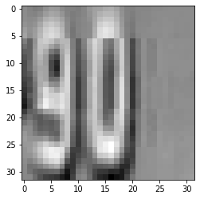

```
Label:  [1. 0. 0. 0. 0. 0. 0. 0. 0. 0.]
```

```python
plt.imshow(X_val[1654],cmap='gray')
plt.show()
print('Label: ', y_val[1654])
```

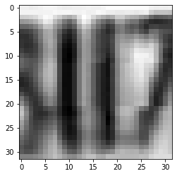

```
Label:  [0. 1. 0. 0. 0. 0. 0. 0. 0. 0.]
```

```python
plt.imshow(X_val[4345],cmap='gray')
plt.show()
print('Label: ', y_val[4345])
```

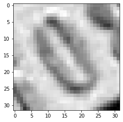

```
Label:  [1. 0. 0. 0. 0. 0. 0. 0. 0. 0.]
```

```python
plt.imshow(X_val[10],cmap='gray')
plt.show()
print('Label: ', y_val[10])
```